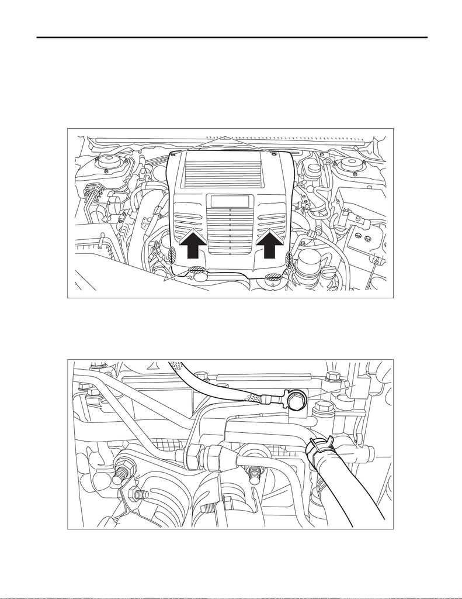

LU(w/o STI)-45

Oil Pipe

LUBRICATION

11.Oil Pipe

A: REMOVAL

1. OIL PIPE ASSY

1) Remove the collector cover.

(1) Remove the clips (A).

(2) Hold the shaded area (B) by hand and carefully pull the RH side (C) upward.

(3) Hold the shaded area (D) by hand and carefully pull the LH side (E) upward.

2) Disconnect the ground terminal from battery sensor. <Ref. to NT-5, BATTERY, NOTE, Note.>

3) Remove the intake duct No. 2. <Ref. to IN(w/o STI)-25, INTAKE DUCT NO. 2, REMOVAL, Intake Duct.>

4) Lift up the vehicle.

5) Remove the under cover. <Ref. to EI-21, REMOVAL, Front Under Cover.>

6) Remove the ground cable (A) from the oil pipe assembly, and disconnect the oil outlet hose (B) from the

oil pipe assembly.

EX-03204

(A)

(B)

(C)

(E)

(D)

LU-03025

(B)

(A)

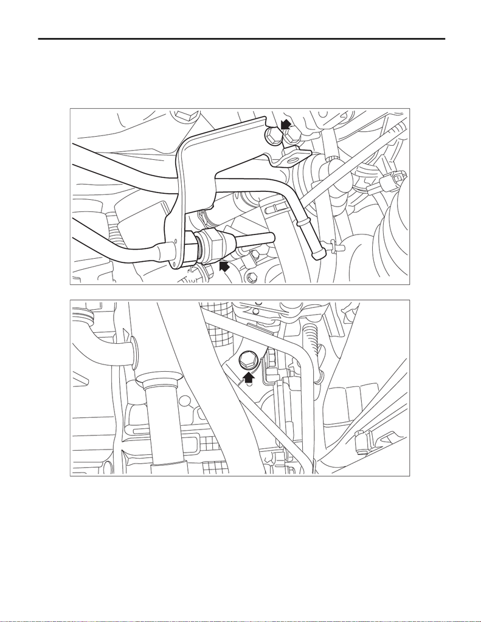

LU(w/o STI)-46

Oil Pipe

LUBRICATION

7) Disconnect the union screw pipe assembly from the oil pipe assembly, and remove the bolt which holds

the oil pipe assembly.

CAUTION:

In order to prevent damaging the oil pipe assembly, fix the section (a) shown in the figure when loos-

ing the flare nut on the union screw pipe assembly, and avoid the part from rotating together while

loosening the nut.

8) Remove the bolt which secures the oil pipe assembly to the cam carrier RH.

9) Lower the vehicle.

(a)

LU-03047

LU-03213

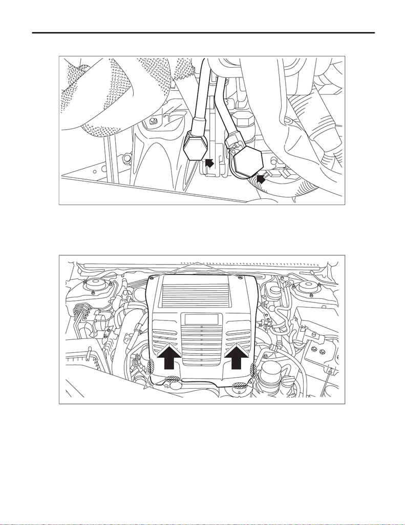

LU(w/o STI)-47

Oil Pipe

LUBRICATION

10) Remove the union bolts which secure the oil pipe assembly from the scavenge pump and the intake rear

camshaft cap RH, and remove the oil pipe assembly.

2. OIL PIPE

1) Remove the collector cover.

(1) Remove the clips (A).

(2) Hold the shaded area (B) by hand and carefully pull the RH side (C) upward.

(3) Hold the shaded area (D) by hand and carefully pull the LH side (E) upward.

2) Remove the intake duct No. 2. <Ref. to IN(w/o STI)-25, INTAKE DUCT NO. 2, REMOVAL, Intake Duct.>

3) Remove the clip (A) which secures the engine harness to the oil pipe and the bolt (B) which secures the

oil pipe to the cam carrier RH.

LU-03026

EX-03204

(A)

(B)

(C)

(E)

(D)

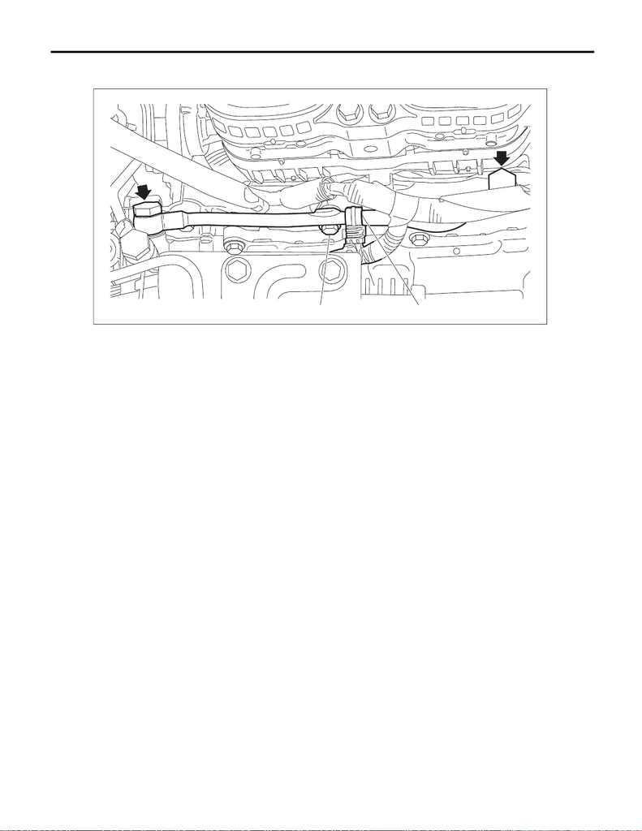

LU(w/o STI)-48

Oil Pipe

LUBRICATION

4) Remove the union bolts which secure the oil pipes from the intake rear camshaft cap RH and the cam car-

rier RH.

B: INSTALLATION

1. OIL PIPE ASSY

1) Temporarily install the oil pipe assembly.

(1) Temporarily tighten the union bolts (B) and (C) which secure the oil pipe assembly (A) to the scavenge

pump and the intake rear camshaft cap RH.

NOTE:

Use a new gasket.

(2) Temporarily tighten the bolts (D) and (E) which secure the oil pipe assembly (A) to the cam carrier RH.

LU-03199

(B) (A)

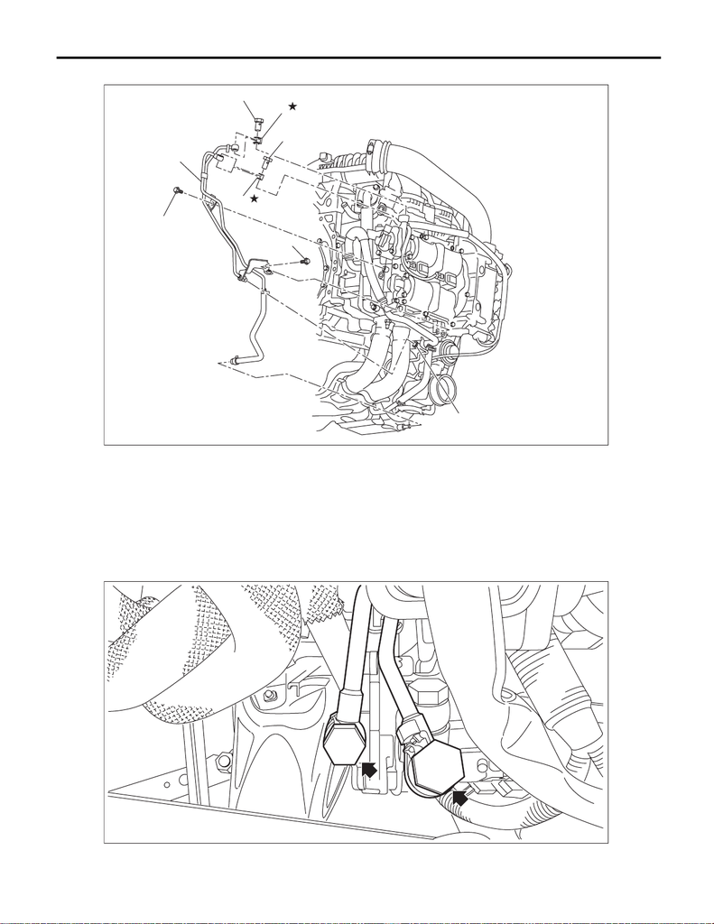

LU(w/o STI)-49

Oil Pipe

LUBRICATION

(3) Temporarily tighten the union screw pipe assembly (F) to the oil pipe assembly (A).

2) Tighten the union bolts which secure the oil pipe assembly to the scavenge pump and the intake rear cam-

shaft cap RH.

Tightening torque:

29 N·m (3.0 kgf-m, 21.4 ft-lb)

3) Lift up the vehicle.

(A) Oil pipe ASSY (B) Union bolt (C) Union bolt

(D) Bolt (E) Bolt (F) Union screw pipe ASSY

(G) Gasket

LU-03200

(C)

(B)

(E)

(A)

(D)

(F)

(G)

(G)

LU-03026

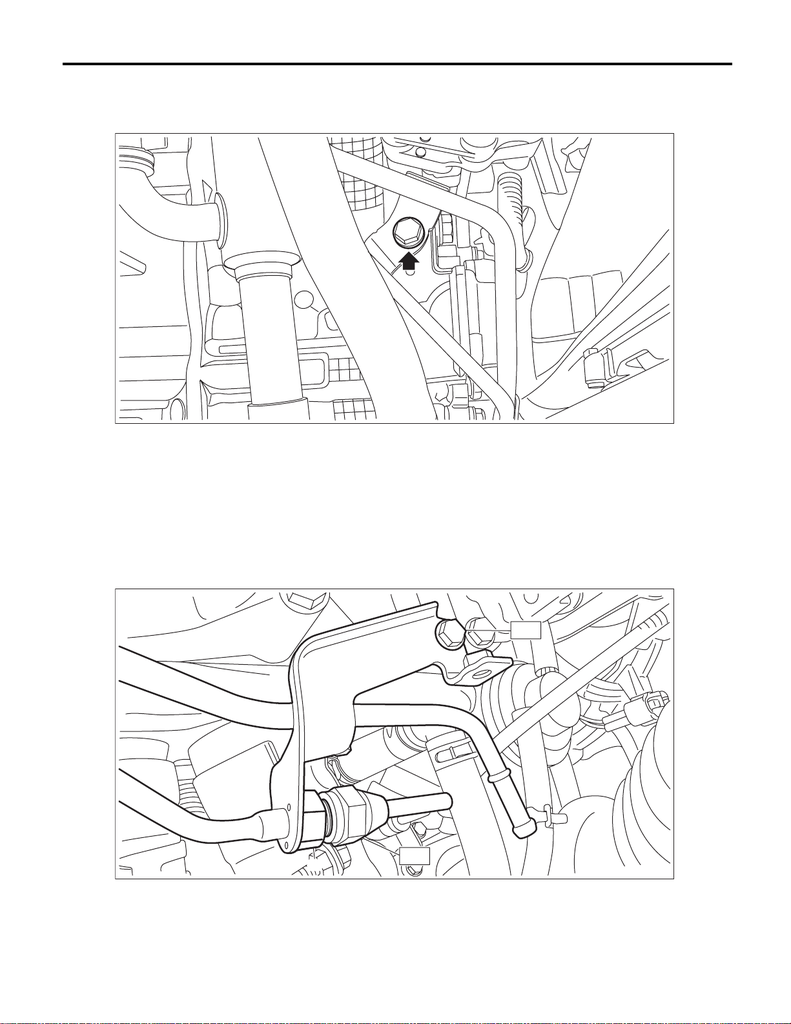

LU(w/o STI)-50

Oil Pipe

LUBRICATION

4) Tighten the bolt which secures the oil pipe assembly to the cam carrier RH.

Tightening torque:

6.4 N·m (0.7 kgf-m, 4.7 ft-lb)

5) Install the bolt which secures the oil pipe assembly, and install the union screw pipe assembly to the oil

pipe assembly.

CAUTION:

In order to prevent damaging the oil pipe assembly, fix the section (a) shown in the figure when tight-

ening the flare nut on the union screw pipe assembly, and avoid the part from rotating together while

tightening the nut.

Tightening torque:

T1: 6.4 N·m (0.7 kgf-m, 4.7 ft-lb)

T2: 20 N·m (2.0 kgf-m, 14.8 ft-lb)

LU-03213

(a)

T1

T2

LU-03059

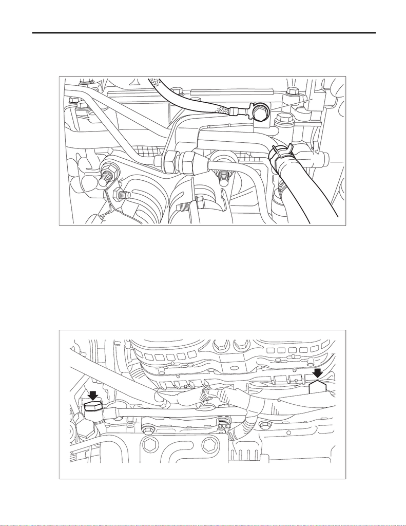

LU(w/o STI)-51

Oil Pipe

LUBRICATION

6) Connect the oil outlet hose (B) to the oil pipe assembly, and install the ground cable (A) to the oil pipe as-

sembly.

Tightening torque:

7 N·m (0.7 kgf-m, 5.2 ft-lb)

7) Install the under cover. <Ref. to EI-22, INSTALLATION, Front Under Cover.>

8) Lower the vehicle.

9) Install the intake duct No. 2. <Ref. to IN(w/o STI)-32, INTAKE DUCT NO. 2, INSTALLATION, Intake

Duct.>

10) Connect the ground terminal to battery sensor. <Ref. to NT-5, BATTERY, NOTE, Note.>

11) Install the collector cover.

2. OIL PIPE

1) Temporarily tighten the union bolts which secure the oil pipes to the intake rear camshaft cap RH and the

cam carrier RH.

NOTE:

Use a new gasket.

LU-03025

(B)

(A)

LU-03202

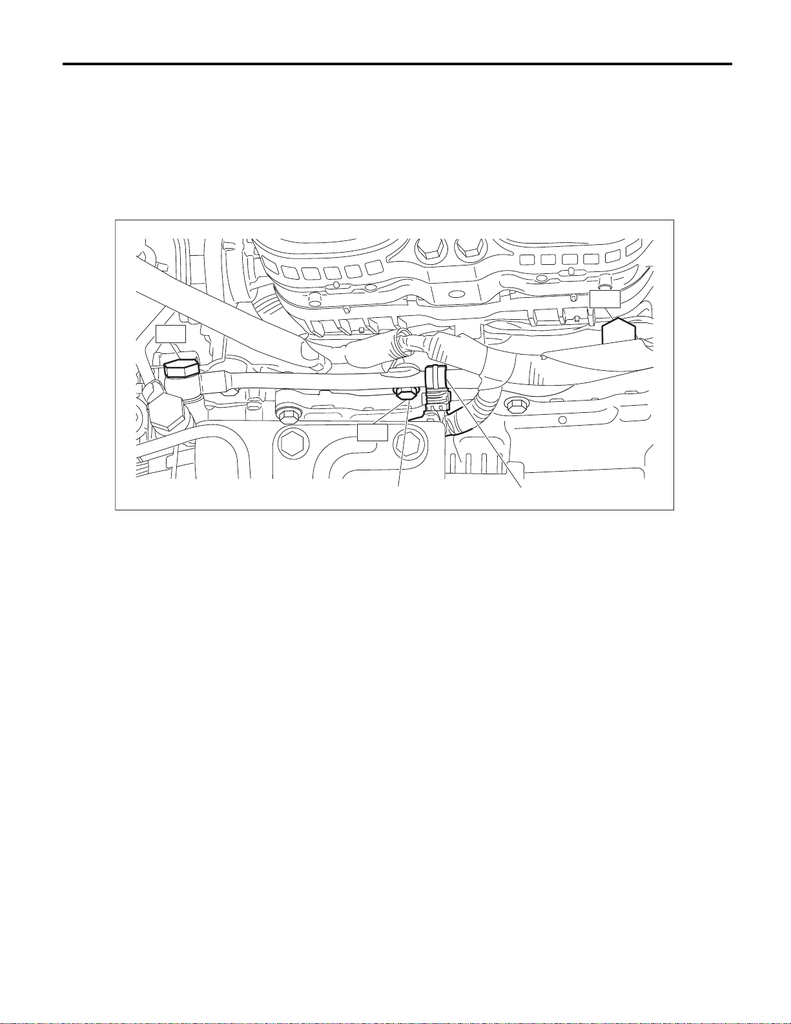

LU(w/o STI)-52

Oil Pipe

LUBRICATION

2) Install the bolt (A) which secures the oil pipe to the cam carrier RH, and install the clip (B) which secures

the engine harness to the oil pipe.

Tightening torque:

T1: 6.4 N·m (0.7 kgf-m, 4.7 ft-lb)

3) Tighten the union bolts which secure the oil pipes to the intake rear camshaft cap RH and the cam carrier

RH.

Tightening torque:

T2: 31 N·m (3.2 kgf-m, 22.9 ft-lb)

4) Install the intake duct No. 2. <Ref. to IN(w/o STI)-32, INTAKE DUCT NO. 2, INSTALLATION, Intake

Duct.>

5) Install the collector cover.

C: INSPECTION

1) Check that the oil pipe assembly, oil pipes, and the union bolts have no deformation, cracks and other

damages.

2) Check that there are no oil leaks or oil oozing from the areas where the oil pipe assembly and oil pipes are

installed.

LU-03201

T1

T2

T2

(A) (B)